## Geocode address and map to census tract

This example starts with a street address and then displays two maps:

- state and county of interest,
- census tracts within county of interest.

Earl F Glynn, UMKC Center for Health Insights, 2014-10-27. Updated 2015-05-07.

### Windows Workaround

Install [R package UScensus2010](http://cran.r-project.org/web/packages/UScensus2010/index.html) normally from CRAN.

This package provides helper function `install.tract` to install census tract data, but some Windows versions have an error that makes `install.tract` fail. (The function only checks R minor version, instead of major and minor versions, and only performs installs if R.Version()$minor is >= 11.)

To get around this bug in Windows, manually enter this:

```
install.packages("UScensus2010tract", repos = "http://lakshmi.calit2.uci.edu/census2000/R/", type = "source")
```

See E-mail exchange with package author Zack W. Almquist About this issue.

### US Census API

The R example below uses the US Census API to find the census tract for a given street address.

For background on this API:

- [US Census Geocoder](http://geocoding.geo.census.gov/geocoder/)
- [Geocoding Services Web Application Programming Interface (API)](http://geocoding.geo.census.gov/geocoder/Geocoding_Services_API.pdf)

### Setup

```r
library(stringr)   # str_trim
library(RJSONIO)   # fromJSON

fix <- function(s)
{
  gsub(" ", "+", str_trim(s))
}

# http://stackoverflow.com/questions/6364783/capitalize-the-first-letter-of-both-words-in-a-two-word-string
simpleCap <- function(x)
{
  s <- strsplit(x, " ")[[1]]
  paste(toupper(substring(s, 1,1)), substring(s, 2),
      sep="", collapse=" ")
}
```

### Test Address: UMKC School of Medicine

```r
street <- "2411 Holmes St"
city   <- "Kansas City"
state  <- "MO"
```

### Output from US Census Geocoder

The output from the online US Census Geocoder [can be seen here](http://geocoding.geo.census.gov/geocoder/geographies/onelineaddress?address=2411+Holmes+St%2C+Kansas+City%2C+MO&benchmark=4&vintage=4).

Form URL for US Census geocoder and parse JSON output:

```r
GEOCODE.PREFIX <- "http://geocoding.geo.census.gov/geocoder/geographies/address?street="
GEOCODE.SUFFIX <- "&benchmark=Public_AR_Census2010&vintage=Census2010_Census2010&layers=14&format=json"

URL <- paste0(GEOCODE.PREFIX, fix(street), "&city=", fix(city), "&state=", fix(state), GEOCODE.SUFFIX)

JSON <- fromJSON(URL)

length(JSON$result$addressMatches)
```

```
## [1] 1
```

```r
stopifnot(length(JSON$result$addressMatches) > 0)
```

Values of interest from geocoder:

```r
target.matched <- JSON$result$addressMatches[[1]]$matchedAddress
target.matched
```

```
## [1] "2411 Holmes St, KANSAS CITY, MO, 64108"
```

```r
target.stateabbr <- JSON$result$addressMatches[[1]]$addressComponents["state"]
target.stateabbr
```

```
## state
##  "MO"
```

```r
target.zip <- JSON$result$addressMatches[[1]]$addressComponents["zip"]
target.zip
```

```
##     zip
## "64108"
```

```r
target.coordinates <- JSON$result$addressMatches[[1]]$coordinates
target.coordinates
```

```
##         x         y
## -94.57584  39.08360
```

It’s unclear why geographies object is a vector here. Make sure there is a least one, but defer decision on how to handle mutiple geographics till later.

See Wikipedia info about FIPS codes.

```r
length(JSON$result$addressMatches[[1]]$geographies$`Census Blocks`)
```

```
## [1] 1
```

```r
stopifnot(length(JSON$result$addressMatches[[1]]$geographies$`Census Blocks`) > 0)

fips.state   <- JSON$result$addressMatches[[1]]$geographies$`Census Blocks`[[1]]$STATE
fips.state
```

```
## [1] "29"
```

```r
fips.county  <- JSON$result$addressMatches[[1]]$geographies$`Census Blocks`[[1]]$COUNTY
fips.county
```

```
## [1] "095"
```

```r
target.tract <- JSON$result$addressMatches[[1]]$geographies$`Census Blocks`[[1]]$TRACT
target.tract  # US Census tract
```

```
## [1] "004300"
```

```r
target.block <- JSON$result$addressMatches[[1]]$geographies$`Census Blocks`[[1]]$BLOCK
target.block  # US Census block
```

```
## [1] "1004"
```

```r
target.geoid <- JSON$result$addressMatches[[1]]$geographies$`Census Blocks`[[1]]$GEOID
target.geoid
```

```
## [1] "290950043001004"
```

### State and County Map

See useful background info about creating maps from 2000 Censusdata –most of the info is applicable to 2010 census data, too: [US Census Spatial and Demographic Data in R](http://www.r-project.org/nosvn/conferences/useR-2010.old/slides/Almquist.pdf).

```r
library(maps)
data(state.fips)
data(county.fips)

fips.state.name <- as.character(state.fips$polyname[ which(as.numeric(fips.state) == state.fips$fips)[1] ])
fips.county.name <- as.character(county.fips$polyname[ county.fips$fips == as.integer(substr(target.geoid,1,5)) ])

# Some states come in parts.  Here only state name wanted.
fips.state.name <- unlist(strsplit(fips.state.name, ":"))[1]
fips.state.name
```

```
## [1] "missouri"
```

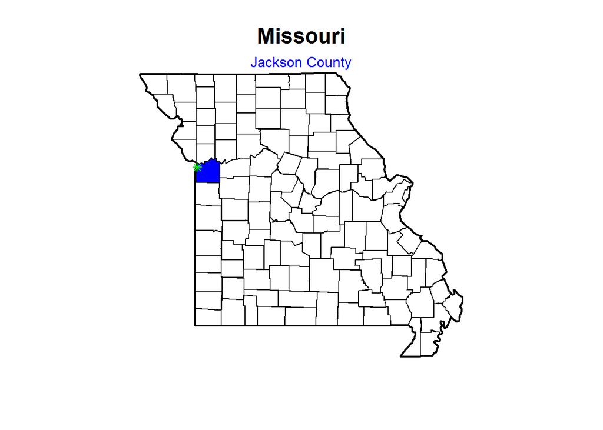

```r
# State
county.info <- map("county", fips.state.name, plot=FALSE)
map("county", fips.state.name,
   fill=TRUE,
   col=ifelse(county.info$names == fips.county.name, "blue", "transparent"))

map("state", fips.state.name, lwd=2, add=TRUE)
title(simpleCap(fips.state.name), cex.main=1.5)

SubdivisionName <- "County"
if (fips.state.name == "alaska")    SubdivsionName <- "Borough"
if (fips.state.name == "louisiana") SubdivsionName <- "Parish"
county.name <- unlist(strsplit(fips.county.name, ","))[2]          # "jackson"
county.name.full <- paste(simpleCap(county.name),SubdivisionName)  # "Jackson County"
mtext(county.name.full, col="blue")

points(target.coordinates["x"], target.coordinates["y"], col="green", pch=8)
```

### Census Tract Map for County

```r
library(UScensus2010)
library(UScensus2010tract)
```

load creates R object, e.g., missouri.tract10, from data read from file.

```r
load(paste0(find.package("UScensus2010tract"), "/data/", fips.state.name, ".tract10.rda"))
```

Assign object (e.g., missouri.tract10) to standard name (state.tract10) for manipulation and delete original name. Because of R’s “lazy loading” this is effectively a rename and does not cause a duplicate copy in memory.

```r
R.statement <- paste0("state.tract10 <- ", fips.state.name, ".tract10;\n",
                      "rm(", fips.state.name, ".tract10)")
connection <- textConnection(R.statement)
R.parse <- parse(connection)
close(connection)
eval(R.parse)
```

### Census Tract Map for County

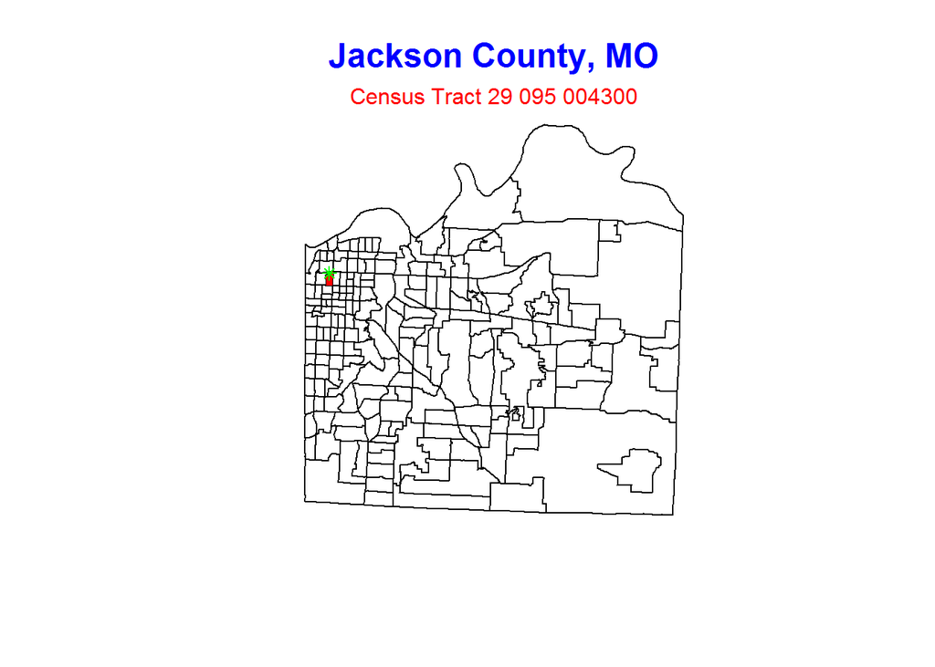

```r
county.coordinates <- county(name=county.name, state=target.stateabbr, level="tract")
plot(county.coordinates)
title(paste0(county.name.full, ", ", target.stateabbr), col.main="blue", cex.main=1.5)

plot(state.tract10,
     col=ifelse(state.tract10@data$tract == target.tract, "red", "transparent"),
     border="transparent",
     add=TRUE)
rm(state.tract10)

tract.parts <- paste(substr(target.geoid,1,2), substr(target.geoid,3,5), substr(target.geoid,6,11))
mtext(paste("Census Tract",tract.parts), col="red")

points(target.coordinates["x"], target.coordinates["y"], col="green", pch=8)
```